# Ensemble Project - Term Deposit Sale (Ver-1)

## Submitted By: Bikram M.Baruah

## Problem Statement : Deliverable – 1 (Exploratory data quality report reflecting the following) – (20)

1. Univariate analysis (12 marks) a. Univariate analysis – data types and description of the independent attributes which should include (name, meaning, range of values observed, central values (mean and median), standard deviation and quartiles, analysis of the body of distributions / tails, missing values, outliers.

b. Strategies to address the different data challenges such as data pollution, outlier’s treatment and missing values treatment.

c. Please provide comments in jupyter notebook regarding the steps you take and insights drawn from the plots.

1. Multivariate analysis (8 marks)

a. Bi-variate analysis between the predictor variables and target column. Comment on your findings in terms of their relationship and degree of relation if any. Visualize the analysis using boxplots and pair plots, histograms or density curves. Select the most appropriate attributes.

b. Please provide comments in jupyter notebook regarding the steps you take and insights drawn from the plots

## Deliverable - 1

```python
#import basic libraries
import pandas as pd
pd.options.display.float_format = '{:,.4f}'.format

import numpy as np

import matplotlib.pyplot as plt
%matplotlib inline

import seaborn as sns
sns.set(color_codes=True)
sns.set_palette("husl")

import warnings
warnings.filterwarnings('ignore')
```

```python
#Reading data
df = pd.read_csv("bank-full.csv")
```

### 1a. Univariate analysis

```python
df.head(20)
```

|  | age | job | marital | education | default | balance | housing | loan | contact | day | month | duration | campaign | pdays | previous | poutcome | Target |
| --- | --- | --- | --- | --- | --- | --- | --- | --- | --- | --- | --- | --- | --- | --- | --- | --- | --- |
| 0 | 58 | management | married | tertiary | no | 2143 | yes | no | unknown | 5 | may | 261 | 1 | -1 | 0 | unknown | no |
| 1 | 44 | technician | single | secondary | no | 29 | yes | no | unknown | 5 | may | 151 | 1 | -1 | 0 | unknown | no |
| 2 | 33 | entrepreneur | married | secondary | no | 2 | yes | yes | unknown | 5 | may | 76 | 1 | -1 | 0 | unknown | no |
| 3 | 47 | blue-collar | married | unknown | no | 1506 | yes | no | unknown | 5 | may | 92 | 1 | -1 | 0 | unknown | no |
| 4 | 33 | unknown | single | unknown | no | 1 | no | no | unknown | 5 | may | 198 | 1 | -1 | 0 | unknown | no |
| 5 | 35 | management | married | tertiary | no | 231 | yes | no | unknown | 5 | may | 139 | 1 | -1 | 0 | unknown | no |
| 6 | 28 | management | single | tertiary | no | 447 | yes | yes | unknown | 5 | may | 217 | 1 | -1 | 0 | unknown | no |
| 7 | 42 | entrepreneur | divorced | tertiary | yes | 2 | yes | no | unknown | 5 | may | 380 | 1 | -1 | 0 | unknown | no |
| 8 | 58 | retired | married | primary | no | 121 | yes | no | unknown | 5 | may | 50 | 1 | -1 | 0 | unknown | no |
| 9 | 43 | technician | single | secondary | no | 593 | yes | no | unknown | 5 | may | 55 | 1 | -1 | 0 | unknown | no |
| 10 | 41 | admin. | divorced | secondary | no | 270 | yes | no | unknown | 5 | may | 222 | 1 | -1 | 0 | unknown | no |
| 11 | 29 | admin. | single | secondary | no | 390 | yes | no | unknown | 5 | may | 137 | 1 | -1 | 0 | unknown | no |
| 12 | 53 | technician | married | secondary | no | 6 | yes | no | unknown | 5 | may | 517 | 1 | -1 | 0 | unknown | no |
| 13 | 58 | technician | married | unknown | no | 71 | yes | no | unknown | 5 | may | 71 | 1 | -1 | 0 | unknown | no |
| 14 | 57 | services | married | secondary | no | 162 | yes | no | unknown | 5 | may | 174 | 1 | -1 | 0 | unknown | no |
| 15 | 51 | retired | married | primary | no | 229 | yes | no | unknown | 5 | may | 353 | 1 | -1 | 0 | unknown | no |
| 16 | 45 | admin. | single | unknown | no | 13 | yes | no | unknown | 5 | may | 98 | 1 | -1 | 0 | unknown | no |
| 17 | 57 | blue-collar | married | primary | no | 52 | yes | no | unknown | 5 | may | 38 | 1 | -1 | 0 | unknown | no |
| 18 | 60 | retired | married | primary | no | 60 | yes | no | unknown | 5 | may | 219 | 1 | -1 | 0 | unknown | no |
| 19 | 33 | services | married | secondary | no | 0 | yes | no | unknown | 5 | may | 54 | 1 | -1 | 0 | unknown | no |

```python
df.tail(20)
```

|  | age | job | marital | education | default | balance | housing | loan | contact | day | month | duration | campaign | pdays | previous | poutcome | Target |
| --- | --- | --- | --- | --- | --- | --- | --- | --- | --- | --- | --- | --- | --- | --- | --- | --- | --- |
| 45191 | 75 | retired | divorced | tertiary | no | 3810 | yes | no | cellular | 16 | nov | 262 | 1 | 183 | 1 | failure | yes |
| 45192 | 29 | management | single | tertiary | no | 765 | no | no | cellular | 16 | nov | 238 | 1 | -1 | 0 | unknown | yes |
| 45193 | 28 | self-employed | single | tertiary | no | 159 | no | no | cellular | 16 | nov | 449 | 2 | 33 | 4 | success | yes |
| 45194 | 59 | management | married | tertiary | no | 138 | yes | yes | cellular | 16 | nov | 162 | 2 | 187 | 5 | failure | no |
| 45195 | 68 | retired | married | secondary | no | 1146 | no | no | cellular | 16 | nov | 212 | 1 | 187 | 6 | success | yes |
| 45196 | 25 | student | single | secondary | no | 358 | no | no | cellular | 16 | nov | 330 | 1 | -1 | 0 | unknown | yes |
| 45197 | 36 | management | single | secondary | no | 1511 | yes | no | cellular | 16 | nov | 270 | 1 | -1 | 0 | unknown | yes |
| 45198 | 37 | management | married | tertiary | no | 1428 | no | no | cellular | 16 | nov | 333 | 2 | -1 | 0 | unknown | no |
| 45199 | 34 | blue-collar | single | secondary | no | 1475 | yes | no | cellular | 16 | nov | 1166 | 3 | 530 | 12 | other | no |
| 45200 | 38 | technician | married | secondary | no | 557 | yes | no | cellular | 16 | nov | 1556 | 4 | -1 | 0 | unknown | yes |
| 45201 | 53 | management | married | tertiary | no | 583 | no | no | cellular | 17 | nov | 226 | 1 | 184 | 4 | success | yes |
| 45202 | 34 | admin. | single | secondary | no | 557 | no | no | cellular | 17 | nov | 224 | 1 | -1 | 0 | unknown | yes |
| 45203 | 23 | student | single | tertiary | no | 113 | no | no | cellular | 17 | nov | 266 | 1 | -1 | 0 | unknown | yes |
| 45204 | 73 | retired | married | secondary | no | 2850 | no | no | cellular | 17 | nov | 300 | 1 | 40 | 8 | failure | yes |
| 45205 | 25 | technician | single | secondary | no | 505 | no | yes | cellular | 17 | nov | 386 | 2 | -1 | 0 | unknown | yes |
| 45206 | 51 | technician | married | tertiary | no | 825 | no | no | cellular | 17 | nov | 977 | 3 | -1 | 0 | unknown | yes |
| 45207 | 71 | retired | divorced | primary | no | 1729 | no | no | cellular | 17 | nov | 456 | 2 | -1 | 0 | unknown | yes |
| 45208 | 72 | retired | married | secondary | no | 5715 | no | no | cellular | 17 | nov | 1127 | 5 | 184 | 3 | success | yes |
| 45209 | 57 | blue-collar | married | secondary | no | 668 | no | no | telephone | 17 | nov | 508 | 4 | -1 | 0 | unknown | no |
| 45210 | 37 | entrepreneur | married | secondary | no | 2971 | no | no | cellular | 17 | nov | 361 | 2 | 188 | 11 | other | no |

```python
df.describe().T
```

|  | count | mean | std | min | 25% | 50% | 75% | max |
| --- | --- | --- | --- | --- | --- | --- | --- | --- |
| age | 45,211.0000 | 40.9362 | 10.6188 | 18.0000 | 33.0000 | 39.0000 | 48.0000 | 95.0000 |
| balance | 45,211.0000 | 1,362.2721 | 3,044.7658 | -8,019.0000 | 72.0000 | 448.0000 | 1,428.0000 | 102,127.0000 |
| day | 45,211.0000 | 15.8064 | 8.3225 | 1.0000 | 8.0000 | 16.0000 | 21.0000 | 31.0000 |
| duration | 45,211.0000 | 258.1631 | 257.5278 | 0.0000 | 103.0000 | 180.0000 | 319.0000 | 4,918.0000 |
| campaign | 45,211.0000 | 2.7638 | 3.0980 | 1.0000 | 1.0000 | 2.0000 | 3.0000 | 63.0000 |
| pdays | 45,211.0000 | 40.1978 | 100.1287 | -1.0000 | -1.0000 | -1.0000 | -1.0000 | 871.0000 |
| previous | 45,211.0000 | 0.5803 | 2.3034 | 0.0000 | 0.0000 | 0.0000 | 0.0000 | 275.0000 |

```python
df.shape
```

```
(45211, 17)
```

```python
df.info()
```

```
<class 'pandas.core.frame.DataFrame'>
RangeIndex: 45211 entries, 0 to 45210
Data columns (total 17 columns):
 #   Column     Non-Null Count  Dtype
---  ------     --------------  -----
 0   age        45211 non-null  int64
 1   job        45211 non-null  object
 2   marital    45211 non-null  object
 3   education  45211 non-null  object
 4   default    45211 non-null  object
 5   balance    45211 non-null  int64
 6   housing    45211 non-null  object
 7   loan       45211 non-null  object
 8   contact    45211 non-null  object
 9   day        45211 non-null  int64
 10  month      45211 non-null  object
 11  duration   45211 non-null  int64
 12  campaign   45211 non-null  int64
 13  pdays      45211 non-null  int64
 14  previous   45211 non-null  int64
 15  poutcome   45211 non-null  object
 16  Target     45211 non-null  object
dtypes: int64(7), object(10)
memory usage: 5.9+ MB
```

```python
def listoutvalues():
    for i in list(df.columns[df.dtypes=='object']):   # checking value counts of all object type columns
        print("COLUMN: ",i)
        print(df[i].value_counts())
        print("-"*30)
        print()
listoutvalues()
```

```
COLUMN:  job
blue-collar      9732
management       9458
technician       7597
admin.           5171
services         4154
retired          2264
self-employed    1579
entrepreneur     1487
unemployed       1303
housemaid        1240
student           938
unknown           288
Name: job, dtype: int64
------------------------------

COLUMN:  marital
married     27214
single      12790
divorced     5207
Name: marital, dtype: int64
------------------------------

COLUMN:  education
secondary    23202
tertiary     13301
primary       6851
unknown       1857
Name: education, dtype: int64
------------------------------

COLUMN:  default
no     44396
yes      815
Name: default, dtype: int64
------------------------------

COLUMN:  housing
yes    25130
no     20081
```

[output cut: 30 more lines]

```
------------------------------

COLUMN:  poutcome
unknown    36959
failure     4901
other       1840
success     1511
Name: poutcome, dtype: int64
------------------------------

COLUMN:  Target
no     39922
yes     5289
Name: Target, dtype: int64
------------------------------
```

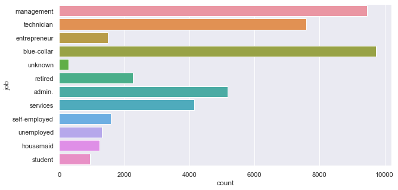

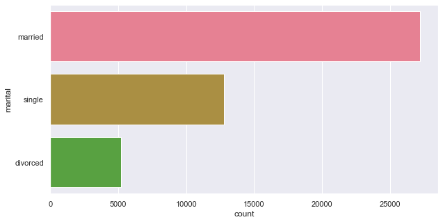

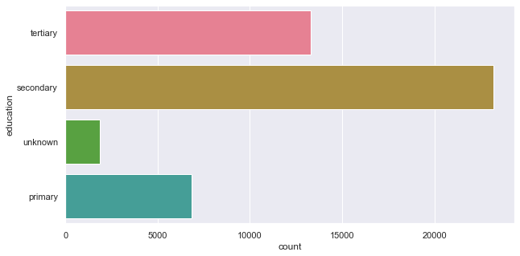

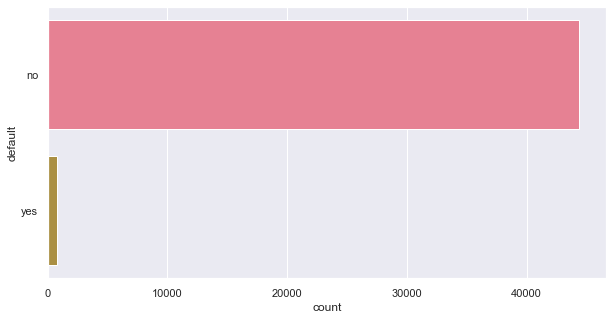

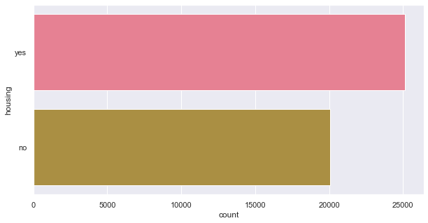

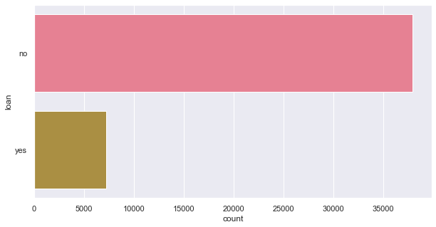

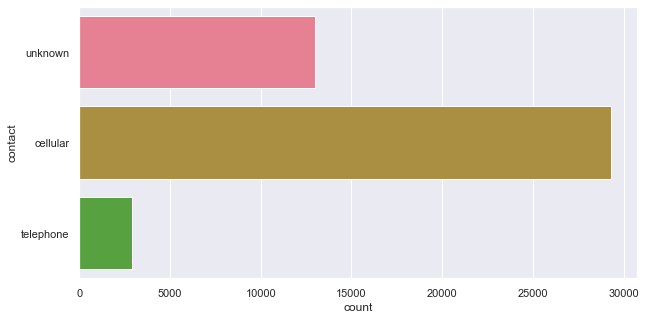

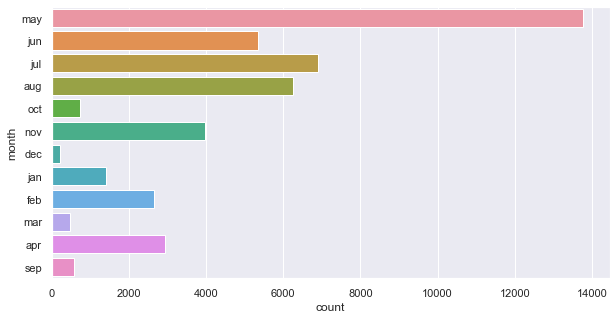

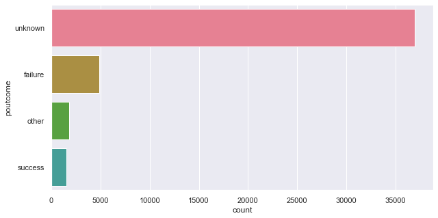

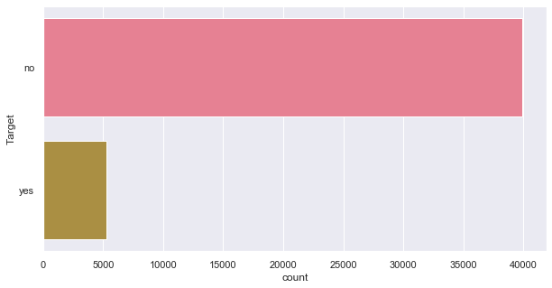

```python
for i in list(df.columns[df.dtypes=='object']):   # checking value counts of all object type columns
    plt.figure(figsize=(10,5))
    sns.countplot(y=df[i])
    plt.show()
```

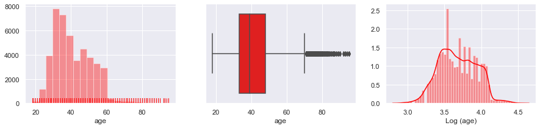

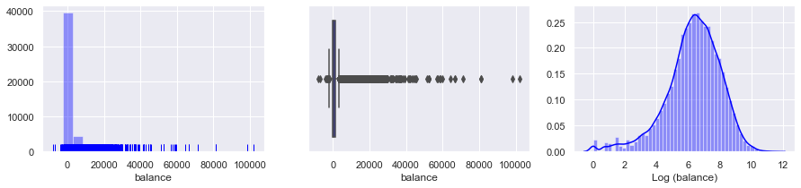

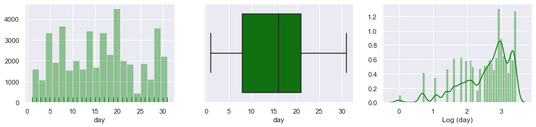

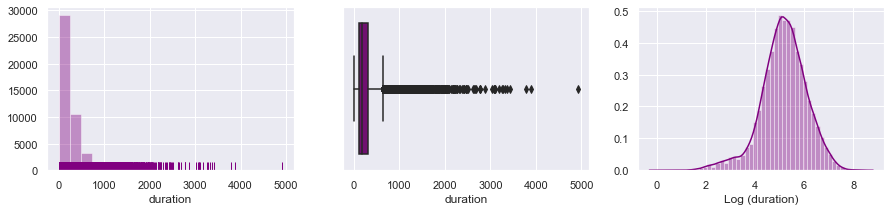

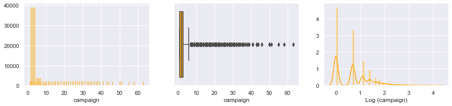

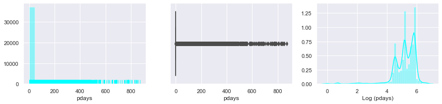

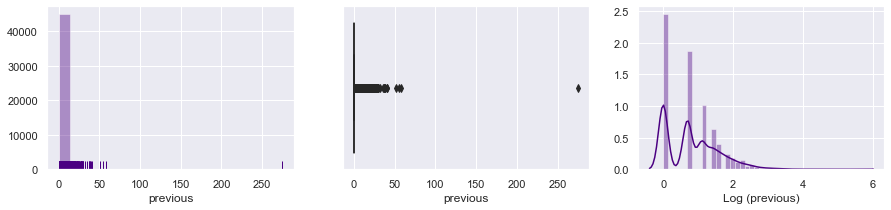

```python
#noneg = lambda x: 900 if -1 else x
#df.pdays = df.pdays.apply(noneg)

colors = ['red','blue','green','purple','orange','cyan','indigo']
def plotua(series, hue, color):
    plt.figure(figsize=(15,3))
    plt.subplot(1,3,1)
    sns.distplot(series, color=color, kde=False, bins=20, rug=True)

    plt.subplot(1,3,2)
    sns.boxplot(series, color=color)

    plt.subplot(1,3,3)
    sns.distplot(np.log(series[series>0]), color=color, axlabel="Log ("+series.name+")")

    plt.show()

for i, c in enumerate(df.columns[df.dtypes=='int64']):   # checking value counts of all object type columns
    plotua(df[c],df.Target, colors[i])
```

**Strategies:**

- The 'unknown' values are considered to be missing values and will be dropped. As the number of 'unknown' is very high, if a single value like mean, modal value is used to replace, there is a risk of data becoming biased.
- For pdays, -1 tells us the person has not been contacted or contactperiod is beyond 900 days. So, -1 will be replaced with 900 so that it remains consistent with length of time the person has been contacted.

## 2. Multivariate analysis

All analysis has been done with respect to the 'Target' variable i.e. "if the client subscribed a term deposit".

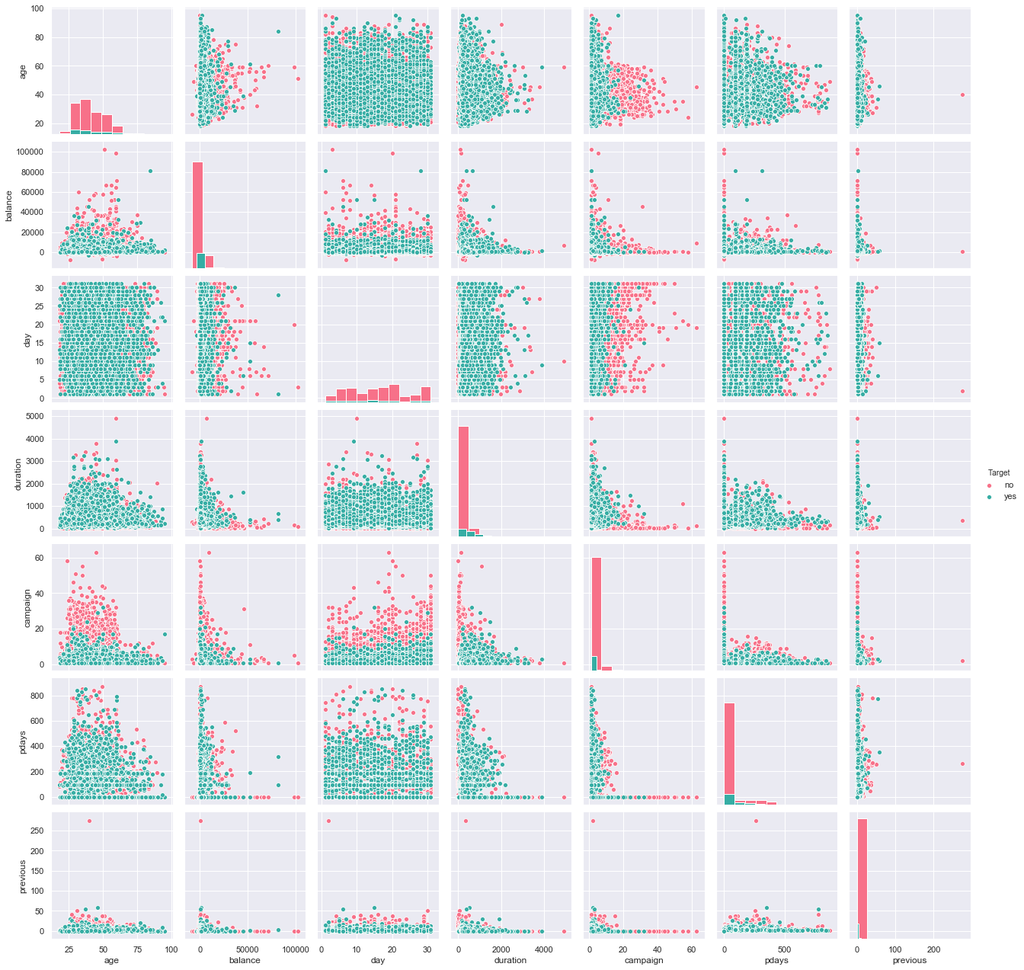

```python
sns.pairplot(df, hue="Target", palette="husl", diag_kind="hist")
```

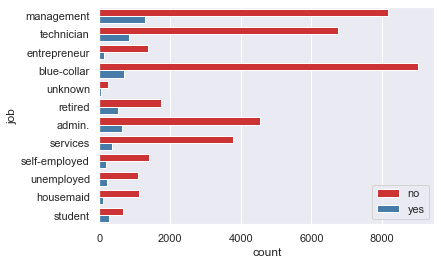

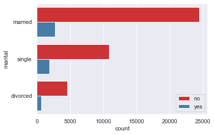

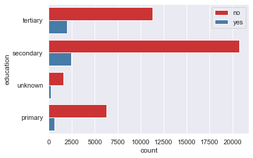

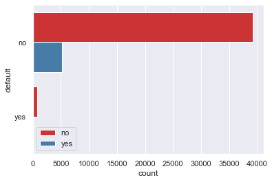

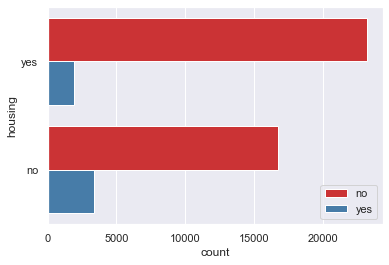

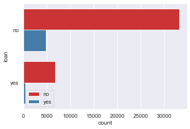

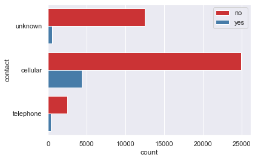

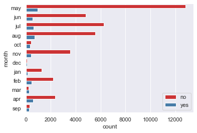

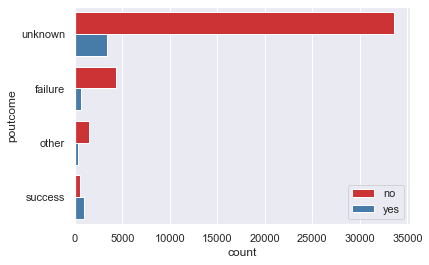

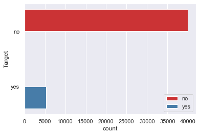

```python
for c in df.columns[df.dtypes=='object']:
    sns.countplot(y=df[c], hue=df["Target"], palette="Set1")
    plt.legend()

    plt.show()
```